# Loan Repayment and borrower analysis

## Other Variables

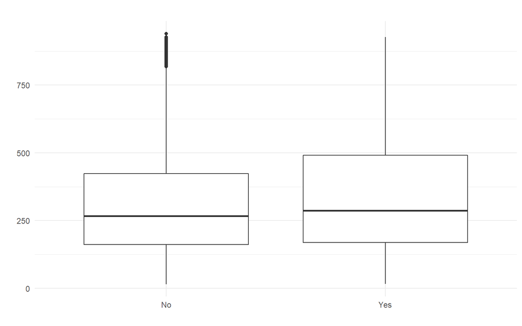

```r
data %>%
  ggplot(aes(x = not.fully.paid, y = installment)) +
  geom_boxplot() +
  theme_minimal() +
  labs(x = "", y = "", title = "")
```

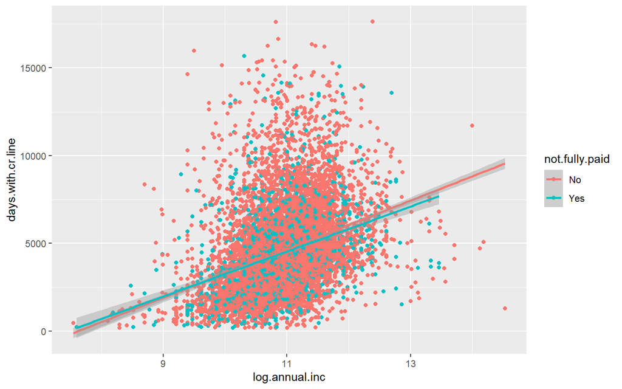

```r
data %>%
  ggplot(aes(x = log.annual.inc, y = days.with.cr.line, color = not.fully.paid)) +
  geom_point() +
  geom_smooth(method = "lm")
```

# Model Analysis

## Determining factors contributing to a person defaulting on the loan

```r
complete_logit <- glm(formula = not.fully.paid ~ . - days - annual.inc, data = data, family = "binomial")
Stepwise_logit <- stepAIC(complete_logit, direction = "both")
```

```
## Start:  AIC=7890.62
## not.fully.paid ~ (credit.policy + purpose + int.rate + installment +
##     log.annual.inc + dti + fico + days.with.cr.line + revol.bal +
##     revol.util + inq.last.6mths + delinq.2yrs + pub.rec + annual.inc +
##     days) - days - annual.inc
##
##                     Df Deviance    AIC
## - dti                1   7852.6 7888.6
## - int.rate           1   7853.4 7889.4
## - days.with.cr.line  1   7853.6 7889.6
## <none>                   7852.6 7890.6
## - delinq.2yrs        1   7855.3 7891.3
## - revol.util         1   7856.2 7892.2
## - pub.rec            1   7858.8 7894.8
## - revol.bal          1   7863.7 7899.7
## - credit.policy      1   7867.6 7903.6
## - fico               1   7893.7 7929.7
## - inq.last.6mths     1   7893.9 7929.9
## - installment        1   7900.0 7936.0
## - log.annual.inc     1   7900.4 7936.4
## - purpose            6   7941.8 7967.8
##
## Step:  AIC=7888.62
## not.fully.paid ~ credit.policy + purpose + int.rate + installment +
##     log.annual.inc + fico + days.with.cr.line + revol.bal + revol.util +
##     inq.last.6mths + delinq.2yrs + pub.rec
##
##                     Df Deviance    AIC
## - int.rate           1   7853.4 7887.4
## - days.with.cr.line  1   7853.6 7887.6
## <none>                   7852.6 7888.6
## - delinq.2yrs        1   7855.3 7889.3
## - revol.util         1   7856.2 7890.2
## + dti                1   7852.6 7890.6
## - pub.rec            1   7858.8 7892.8
## - revol.bal          1   7863.9 7897.9
## - credit.policy      1   7867.6 7901.6
## - fico               1   7893.7 7927.7
## - inq.last.6mths     1   7893.9 7927.9
## - installment        1   7900.0 7934.0
```

[output cut: 29 more lines]

```
##                     Df Deviance    AIC
## <none>                   7854.4 7886.4
## - delinq.2yrs        1   7856.5 7886.5
## + days.with.cr.line  1   7853.4 7887.4
## + int.rate           1   7853.6 7887.6
## + dti                1   7854.4 7888.4
## - revol.util         1   7858.9 7888.9
## - pub.rec            1   7861.4 7891.4
## - revol.bal          1   7866.8 7896.8
## - credit.policy      1   7869.4 7899.4
## - inq.last.6mths     1   7897.0 7927.0
## - log.annual.inc     1   7902.2 7932.2
## - installment        1   7916.5 7946.5
## - fico               1   7931.0 7961.0
## - purpose            6   7954.6 7974.6
```

```r
vif_scores <- vif(Stepwise_logit)
tidy_logit <- tidy(Stepwise_logit, exponentiate = TRUE, conf.int = TRUE)
knitr::kable(tidy_logit)
```

| term | estimate | std.error | statistic | p.value | conf.low | conf.high |
| --- | --- | --- | --- | --- | --- | --- |
| (Intercept) | 8184.9836676 | 0.9574034 | 9.4109300 | 0.0000000 | 1260.2674126 | 5.377023e+04 |
| credit.policyYes | 0.7200077 | 0.0840652 | -3.9076043 | 0.0000932 | 0.6111012 | 8.496664e-01 |
| purposecredit_card | 0.5855331 | 0.1086417 | -4.9265876 | 0.0000008 | 0.4721123 | 7.229470e-01 |
| purposedebt_consolidation | 0.7136064 | 0.0766541 | -4.4019015 | 0.0000107 | 0.6142386 | 8.295895e-01 |
| purposeeducational | 1.0725909 | 0.1519086 | 0.4613108 | 0.6445756 | 0.7917235 | 1.437155e+00 |
| purposehome_improvement | 1.1067191 | 0.1261605 | 0.8037373 | 0.4215487 | 0.8613593 | 1.412959e+00 |
| purposemajor_purchase | 0.7030850 | 0.1660997 | -2.1208794 | 0.0339320 | 0.5025937 | 9.650172e-01 |
| purposesmall_business | 1.7542895 | 0.1137315 | 4.9420233 | 0.0000008 | 1.4018471 | 2.189792e+00 |
| installment | 1.0012720 | 0.0001604 | 7.9264708 | 0.0000000 | 1.0009570 | 1.001587e+00 |
| log.annual.inc | 0.6716968 | 0.0580470 | -6.8556239 | 0.0000000 | 0.5992725 | 7.524057e-01 |
| fico | 0.9905614 | 0.0010962 | -8.6512217 | 0.0000000 | 0.9884283 | 9.926854e-01 |
| revol.bal | 1.0000031 | 0.0000009 | 3.3815248 | 0.0007208 | 1.0000014 | 1.000005e+00 |
| revol.util | 1.0026568 | 0.0012454 | 2.1305525 | 0.0331260 | 1.0002131 | 1.005108e+00 |
| inq.last.6mths | 1.0918530 | 0.0137053 | 6.4118349 | 0.0000000 | 1.0631492 | 1.121862e+00 |
| delinq.2yrs | 0.9256612 | 0.0542118 | -1.4249099 | 0.1541833 | 0.8293976 | 1.026024e+00 |
| pub.rec | 1.2968174 | 0.0964019 | 2.6961397 | 0.0070148 | 1.0705394 | 1.563179e+00 |

```r
knitr::kable(vif_scores)
```

|  | GVIF | Df | GVIF^(1/(2*Df)) |
| --- | --- | --- | --- |
| credit.policy | 1.757511 | 1 | 1.325712 |
| purpose | 1.263994 | 6 | 1.019715 |
| installment | 1.478864 | 1 | 1.216085 |
| log.annual.inc | 1.625008 | 1 | 1.274758 |
| fico | 1.734076 | 1 | 1.316843 |
| revol.bal | 1.391217 | 1 | 1.179499 |
| revol.util | 1.532775 | 1 | 1.238053 |
| inq.last.6mths | 1.515653 | 1 | 1.231118 |
| delinq.2yrs | 1.089436 | 1 | 1.043761 |
| pub.rec | 1.030185 | 1 | 1.014980 |

When running a complete first order model, for a logistic regression, most of the variables appear to have significance. In addition, levels in the purpose variable can be consolidated. The above results show the odds ratio of the model as they have already been transformed using tidy. Moreover, un unexpectedly, the vif score is drastically that what I was expecting showing that each variable was able to capture more of the model despite their relationships.